## Elements Of Data Science - S2022

# Introduction to Data Science Tools

### 1/18/2022

# TODOs

- **Read** Preface of PDSH
- **Read** Ch 1 of PDSH
- **Read** Ch 1 of HOML
- **Skim** Ch 2 of PDSH: Introduction to NumPy
- Complete Weekly Quiz 01

# TODAY

- Software tools we'll be using

# Our Python Data Science Stack

- Python (3.9): Programming language
- Anaconda : Package maintenance and environments
- Jupyter : IDE
- Git : Source control and versioning

# Aside: The Terminal and The Shell

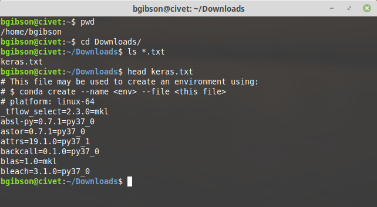

- If not familiar, get aquainted
- Common set of commands (Ex. cd, ls, cat, mv)
- OSX and Linux: Terminal + bash/zsh (already installed)
- Windows: install Git Bash (or use WSL)

# Aside: Common Shell Commands

- **cd** : change directory
- **pwd** : where am i
- **ls** : list directory contents
- **head/tail** : print the beginning/end of a file
- **cat** : print entire file
- **less** : open a file in a pager
- **rm** : remove file
- **which** : path to executable
- ...
- [Basic Shell Commands](https://www.geeksforgeeks.org/basic-shell-commands-in-linux/)
- [Links to Tutorials](https://www.liquidweb.com/kb/basic-bash-shell-commands-a-cli-tutorial/)

# Data Science Life Skills

- Data munging
- Visualization
- Statistical analysis
- Machine learning
- Reporting
- Prototyping
- Productionizing...

# Why Python?

- Robust and active DS stack
- Cross-platform
- Relatively low learning curve
- Fast to answers and prototypes
- Many other good languages and frameworks (R, Scala, etc.)

# Why Python?

- But isn't python slow?
- **Issues:**
  - GIL (Global Interpereter Lock)
  - dynamic typing
- **Solutions:**
  - numpy + vectorization
  - multiprocessing
  - pypy instead of CPython
  - distributed processeing with pyspark?
- Article discussing issues and fixes: ["Are your Python programs running slow?..."](https://bit.ly/2NufScx)

# The Python DS Stack

- **Data munging** : pandas, numpy
- **Visualization** : matplotlib, seaborn, plotly
- **Statistical analysis** : scipy, statsmodels, patsy
- **Machine learning** : scikit-learn, tensorflow, pytorch
- **Reporting** : jupyter+ipython, dash
- **Prototyping** : flask
- **Productionizing...**

# Python 2 vs 3

- We'll be using Python 3.9
- Python 2 end of life was Jan 1, 2020
- Need python 2 for another class? Virtual environments!

# How To Get Python

- You might already have it
- But your OS needs it!
- Our solution: Anaconda

# Why Anaconda?

[figure not shown]

https://imgs.xkcd.com/comics/python_environment.png

# Why Anaconda?

- includes most of what we need by default
- package curation
- dependency control
- conda virtual environments
- cross-platform

# Installing Anaconda

- Download via https://www.anaconda.com/products/individual
- Select OS and Grab Python 3.9 version
- Install somewhere easy to navigate to
  - /home/bgibson/anaconda3
  - C:\Users\brygib\anaconda3
- Recommend letting installer run `conda init` to set up your shell
- Note: base environment activated by default
  - To Turn off:

    `conda config --set auto_activate_base false`

# Running Python

- via terminal:
  - python REPL
  - python command line
  - python script
  - ipython REPL
- via jupyter
- via other IDE
- online via Google Colab
- ...

# Running Python

- Via REPL (Read–Eval–Print Loop)
  - `$ conda activate`
  - `(base)$ python`

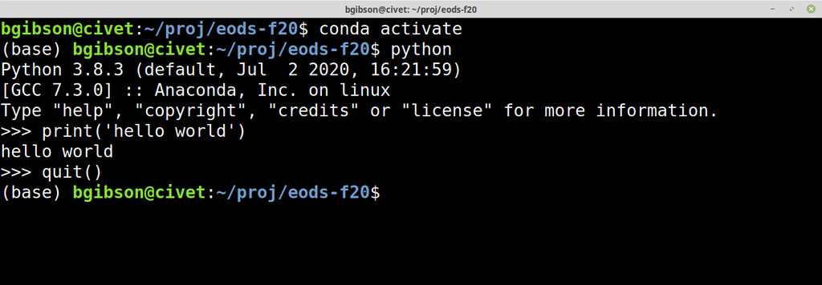

- quit() or Ctrl-D to exit

# Running Python

Via command line

```
(base) bgibson@civet:~$ python -c "print('hello')"
hello
```

Via script

```
(base) bgibson@civet:~$ echo "print('hello')" > /tmp/say_hello.py
(base) bgibson@civet:~$ python /tmp/say_hello.py
hello
```

# Ipython: Interactive Python

- history (`python` does this now as well)
- tab completion (`python` does this now as well)
- "magic" commands
- help via `?` (`python` has `help()` as well)
- (see PDSH Ch 1 for more info)

# Ipython : REPL and Help

- `$conda activate` if (base) not activated

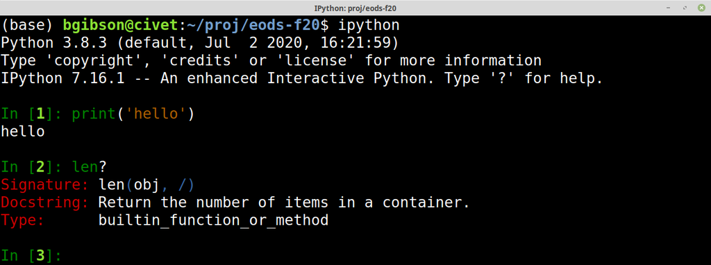

# Ipython Magic Commands

- preceded by % for line, %% for cell

```python
!mkdir tmp
```

```python
!echo print("Welcome to STAT5293: Hello from ipython!") > .\tmp\say_hello.py
```

```python
%run .\tmp\say_hello.py
```

```
Welcome to STAT5293: Hello from ipython!
```

```python
%timeit sorted([5,1,2,5])
```

```
265 ns ± 12.5 ns per loop (mean ± std. dev. of 7 runs, 1000000 loops each)
```

```python
%%timeit
x = []
for i in range(20):
    x.append(i**2)
```

```
5.86 µs ± 318 ns per loop (mean ± std. dev. of 7 runs, 100000 loops each)
```

# Help with Magic Commands

- get information about the %timeit magic function

  ```
  %timeit?
  ```

- get info on all magic functions

  ```
  %magic
  ```

- get list of magic functions

  ```
  %lsmagic
  ```

# Ipython Notebooks with Jupyter

- Jupyter: application that combines code, markup and visualizations
- interact via web browser
- notebooks are easily sharable
- Jupyter can run other kernels as well: R, Julia, C#, etc.
- To launch via command line:

  ```
  (base) bgibson@civet:~$ cd ~/proj
  (base) bgibson@civet:~/proj$ jupyter notebook
  ```

- launches dashboard in your default browser
- Ctrl-C to kill server

# Other IDEs

- jupyterlab
- spyder
- pycharm
- visual studio code ...

# Arguments for Notebooks

- fast to iterate
- easy to test new ideas
- wide adoption

# Arguments against notebooks

- out of order execution
- messy code
- issues with version control
- [slides by Joel Grus](https://conferences.oreilly.com/jupyter/jup-ny/public/schedule/detail/68282)

# How to deal with version issues? Virtual Environments

- encapsulate python executable and packages
- allow for easy experimentation
- workaround versioning issues
- two major implementations: virtualenv and conda (we'll be using conda)

# Virtual Environments with Conda

Example for creating a new environment called py2 with python=2.7:

```
(base) bgibson@civet:~$ conda create -n py2 python=2.7
...
```

```
(base) bgibson@civet:~$ conda activate py2
```

```
(py2) bgibson@civet:~$ which python
/home/bgibson/anaconda3/envs/py2/bin/python
```

```
(py2) bgibson@civet:~$ python --version
Python 2.7.18 :: Anaconda, Inc.
```

```
(py2) bgibson@civet:~$ conda deactivate
```

```
(base) bgibson@civet:~$ which python
/home/bgibson/anaconda3/bin/python
```

```
(base) bgibson@civet:~$ python --version
Python 3.9.7
```

# Managing Conda Enviroments

- `conda create -n [env_name]`
- `conda create -n [env_name] [package] [package]=[version]`
- `conda env create --file [requirementsfile].yml`
- `conda activate [name]`
- `conda deactivate`
- `conda env list`
- For more information see: https://docs.conda.io/projects/conda/en/latest/user-guide/tasks/manage-environments.html

# Installing New Packages

- Again, don't want to mess with system packages!
1. first, try conda:

   ```
   conda install -n [env_name] [package]
   ```

2. next, try another channel : eg. conda-forge

   ```
   conda install -n [env_name] -c conda-forge [package]
   ```

3. lastly, try pip:

   ```
   conda activate [env_name]
   pip install [package]
   ```

- when you can, double check the path to your env

# Conda Envs and Jupyter

- jupyter can run many different kernels
- conda envs not automatically added as available kernels
- to install a new kernel in jupyter:

  ```
  (base) $ conda activate py2
  (py2) $ conda install ipykernel
  (py2) $ python -m ipykernel install --user --name py2
  ```

- to list kernels: `jupyter kernelspec list`
- to remove kernel: `jupyter kernelspec uninstall [name]`

# Jupyter Demo

- Important: h for help
- Markdown syntax help: https://daringfireball.net/projects/markdown/syntax

# Example Notebooks

https://github.com/jupyter/jupyter/wiki/A-gallery-of-interesting-Jupyter-Notebooks

# Git and Github

[figure not shown]

http://imgs.xkcd.com/comics/git.png

# Git

- distributed version control
- for code, documentation, *small* data
- can but used locally or with remote collaborators

# Github

- backup
- sharing
- used for both large and small projects
  - Ex: https://github.com/scikit-learn/scikit-learn

# Getting course material

- Can view online at: https://github.com/cueods/eods-s22
- You'll also want to clone locally:

  ```
  $ cd [your projects folder]
  $ git clone https://github.com/cueods/eods-s22
  ```

# Demo Week 1 Quiz

# Questions?

- Next time: Python review, numpy and pandas